**Force**

By Prof. Seungchul Lee  
http://iai.postech.ac.kr/  
Industrial AI Lab at POSTECH

Table of Contents

# 1. Newton's First Law

- when no force acts on a body, it will remain at rest or maintain uniform motion
- when a force is applied to a body, it will change its state of motion

# 2. Netwon's Second Law

## 2.1. Force

- Vector

$$\begin{align*} \vec F &\propto \vec a \\ \vec F &= m \cdot \vec a\\ & \quad\uparrow\\ &\text{Constant} \end{align*}$$

- $\vec F$ is proportinal to $\vec a$, and $m$ is nothing but a constant
- invisible
- change of velocity
- Mass is different from weight

### Same force

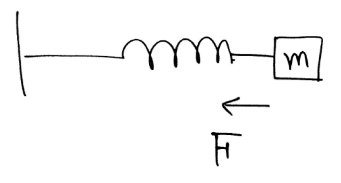

$$\begin{align*} m_1 & a_1 \\ m_2 & a_2 \\ \\ m_1 a_1 &= m_2 a_2 \end{align*}$$

### Same mass

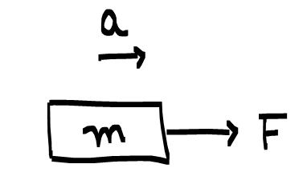

$$\begin{array} \quad & m &\\ F_1 & & a_1\\ F_2 & & a_2\\ &\vdots&\\ \\ \end{array}$$ $$ \frac{F_1}{a_1}=\frac{F_2}{a_2}=m $$

- Newton's 2nd Law

$$\begin{array}{c} \vec F = m \vec a\\ \end{array}$$

- Mass is resistance to rate of change of velocity

## 2.2. Free Body Diagram (F.B.D.)

- Force is a vector concept
- Total force (or net force) is a vector sum of individual forces acting on the body from surroundings
- Consider one object (the system of interest)

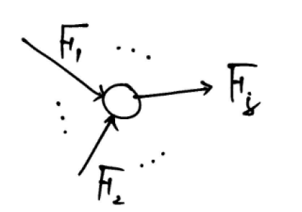

$$\vec F_T = \sum\limits_{i} \vec{F}_i$$

```matlab
%%html
<iframe
width="560" height="315" src="https://www.youtube.com/embed/pcFtlYNq2O0?list=PLBD_gON7g_m1ZBQxsjMPckhutDgGrzBj3"
frameborder="0" allowfullscreen>
</iframe>
```

[video not shown]

```matlab
%%html
<iframe
width="560" height="315" src="https://www.youtube.com/embed/cTQ7lDGWgDg?list=PLBD_gON7g_m1ZBQxsjMPckhutDgGrzBj3"
frameborder="0" allowfullscreen>
</iframe>
```

[video not shown]

## 2.3. Gravitational force near the Earth

$$ \begin{align*} \vec g &\equiv \text{ gravitational force acting on an unit mass} \\ \vec F &= m \vec g \text{ : gravitational force acting on mass } m \end{align*}$$

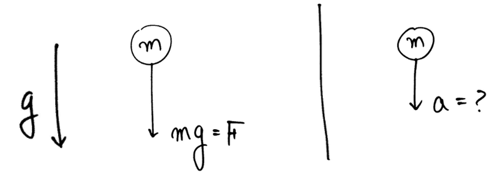

$$F = m \cdot a$$ $$\therefore \; \space a = g$$ - can be used to generate a constant force (or constant acceleration)

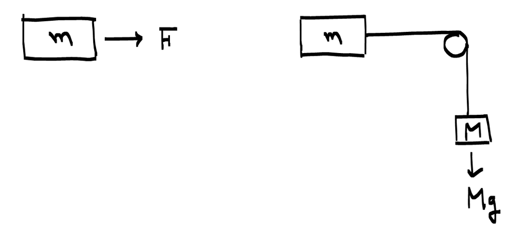

## 2.4. Normal force

- Perpendicular to the surface (surface being a plane) of *contact*
- Here *normal* refers to the geometry terminology for being perpendicular

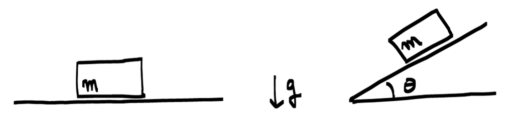

## 2.5. Spring force (Hooke's law)

```matlab
%%html
<iframe
width="420" height="315" src="https://www.youtube.com/embed/9BRUEIHwaU0" frameborder="0" allowfullscreen>
</iframe>
```

[video not shown]

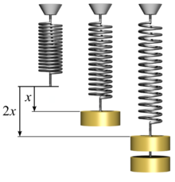

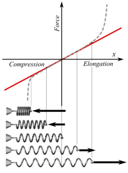

$$\begin{align*} & \Large F = -kx \\ &\text{(idealized)} \end{align*}$$

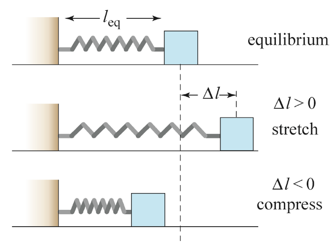

- Force is proportional to a displacement (the amount of deformation)
  - example: a scale
- negative sign: restoring force (directed back toward the equilibrium position of the system)
- an idealized spring is a linear device that can generate force $F = -kx$

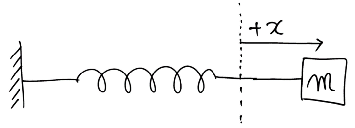

| $$\text{F.B.D.}$$ $$F = -kx$$ | $$\text{Kinematics}$$ $$\underrightarrow{+} \quad a$$ |
| --- | --- |

$$ \begin{align*} F &= ma \\ -kx &= ma \end{align*}$$

- acceleration is changing over time or displacement (not a constant acceleration any more)

$$ -kx = m\frac{d^2x}{dt^2} \implies m\frac{d^2x(t)}{dt^2} + kx(t) = 0$$

```matlab
%%html
<iframe
width="420" height="315" src="https://www.youtube.com/embed/KjTa6b6mCv4" frameborder="0" allowfullscreen>
</iframe>
```

[video not shown]

### Numerical solution of simple harmonic motion

```matlab
m = 1.0;    % kg
k = 100.0;    % N/m
g = 9.8;    % m/sˆ2
v0 = 0.0;    % in m/s
time = 2.0;    % s
dt = 0.0001; % s
n = ceil(time/dt);
t = zeros(n,1);
y = zeros(n,1);
v = zeros(n,1);
a = zeros(n,1);
y(1) = 0.0;
v(1) = v0;
a(1) = -k*y(1) - m*g;

for i = 1:n-1
    F = -k*y(i) - m*g;
    a(i+1) = F/m;
    v(i+1) = v(i) + a(i+1)*dt;
    y(i+1) = y(i) + v(i+1)*dt;
    t(i+1) = t(i) + dt;
end
```

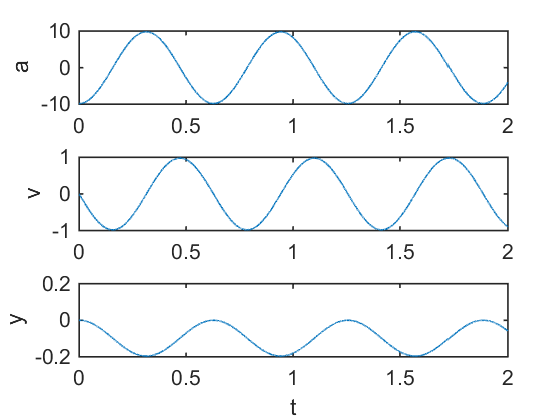

```matlab
subplot(3,1,1), plot(t,a), ylabel('a')
subplot(3,1,2), plot(t,v), ylabel('v')
subplot(3,1,3), plot(t,y), ylabel('y'), xlabel('t')
```

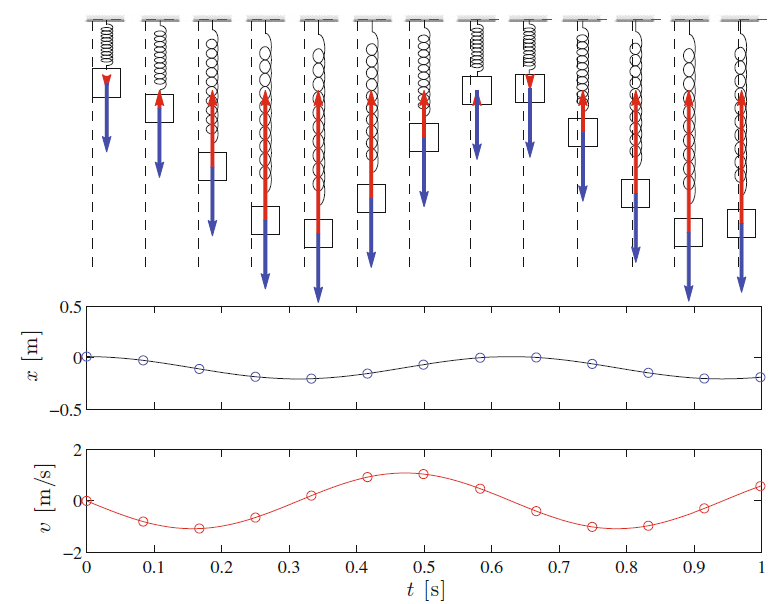

# 3. Newton’s Third Law: Action-Reaction Pairs

- When two bodies interact via a force, then the force on one body is equal in magnitude and opposite in direction to the force acting on the other body

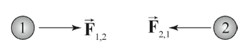

$$\vec{F}_{1,2} = - \vec{F}_{2,1}$$

**Question**

Consider a car at rest on a level surface. We can conclude that the downward gravitational pull of Earth on the car and upward contact force of Earth on it are equal and opposite because

1. The two forces from an interaction pair
2. The net force on the car is zero
3. Neither of the above
4. Unsure

## 3.1. Example

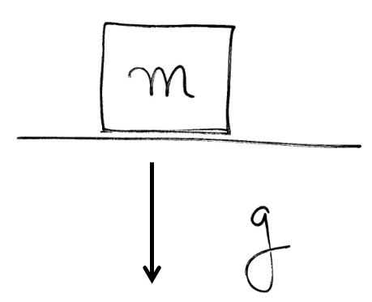

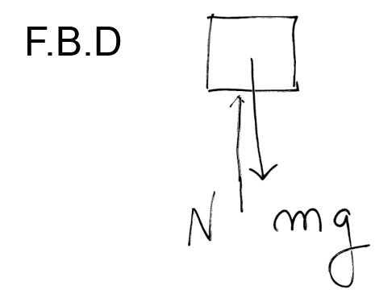

- Think about all forces acting on $m$
  - $mg$, pulled down by the earth (non-contact)
  - $N$, pushed up by the table (contact)
- $m$ is at rest $(a = 0)$

  $\implies $ No total external forces $(N = mg)$
- Action & Reaction forces between two objects

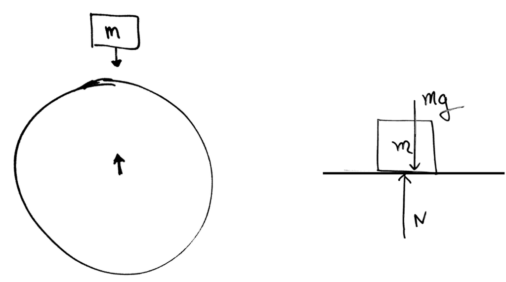

## 3.2. Example - push

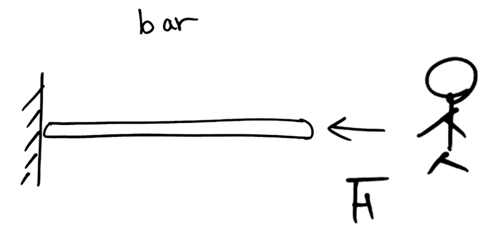

$$\text{Person}$$

$$\text{Bar}$$

$$\text{Wall}$$

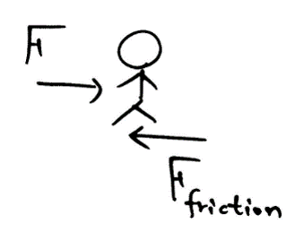

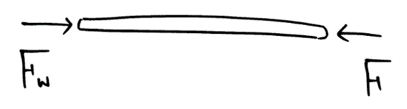

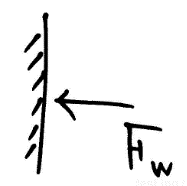

$$\lvert F \rvert = \lvert F_{\text{friction}} \rvert = \lvert F_{\text{wall}} \rvert$$

## 3.3. Example - pull

Person $A$ is pulling a string with force $F$. Tell all forces

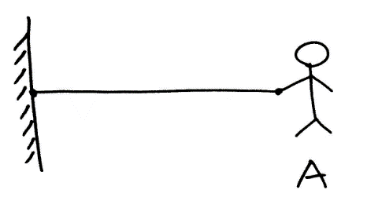

- String

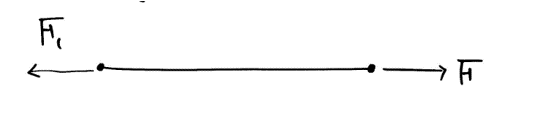

$$ \begin{array}{l} F_1 \text{ (by wall) }\\ a_s = 0 \end{array} $$

$\implies F_1 = F \text{ [from Newton's } 2^{nd} \text{ Law] }$

- Wall

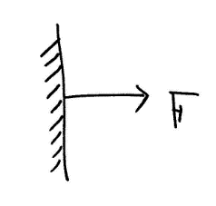

$$ \text{A wall is pulling a string by $F$}$$ $$\begin{align*} \\ M_w a_w &= F \\ a_w &= 0 \quad (\because M \rightarrow \infty) \end{align*}$$

$\implies \text{ A string is pulling a wall by } F \text{ [from Newton's } 3^{rd} \text{ Law]}$

- Persion A

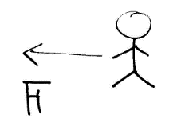

$$\text{A string is pulling person A by } F \text{ [from Newton's } 3^{rd} \text{ Law]}$$

$$a_A = 0 $$$$\text{Why?} \quad \text{Friction}$$

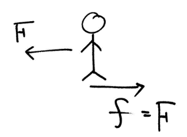

**Question**

A body of mass $m$ is suspended from a spring with spring constant $k$ in configuration (a) and the spring is stretched $0.1$m. If two identical bodies of mass $\frac{m}{2}$ are suspended from a spring with the same spring constant $k$ in configuration (b), how much will the spring stretch? Explain your answer.

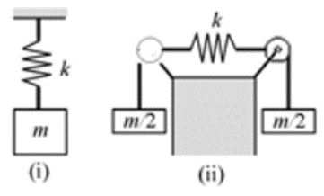

## Exercises

**Problem 1**

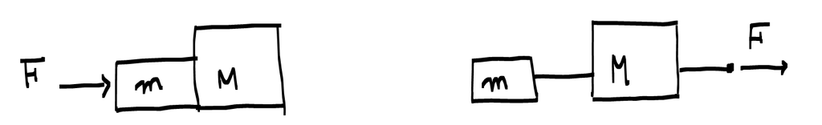

**Problem 2**

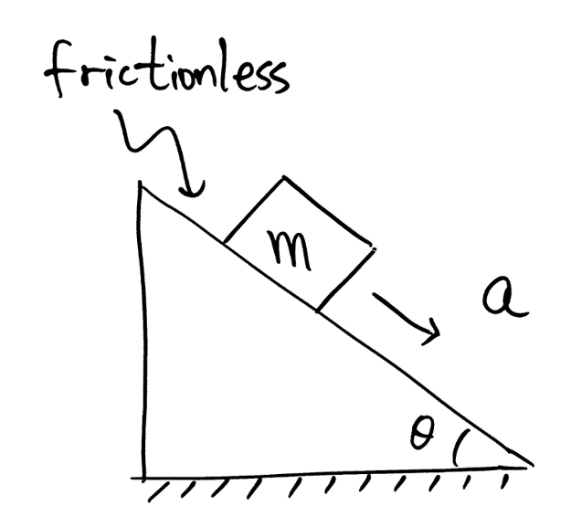

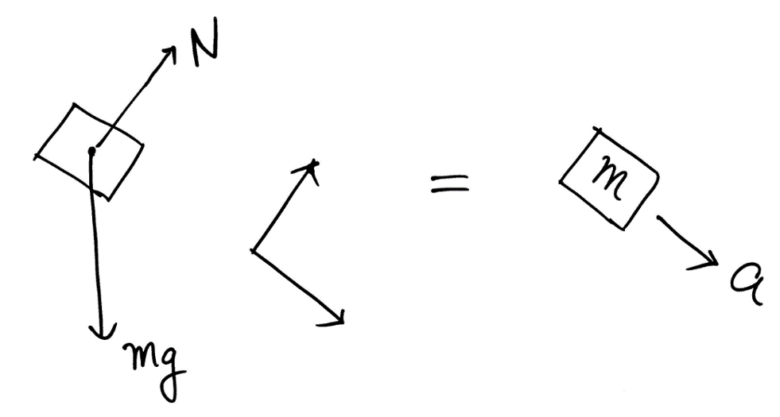

**Problem 3**

Find $\vec a$ for $m$ and $M$

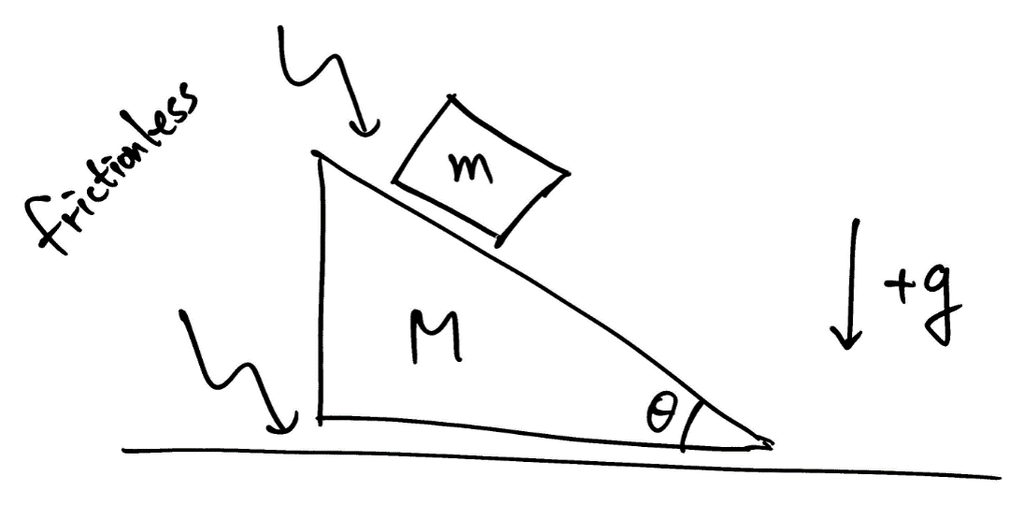